# Lab-4: Assignment

Author

Brian Kwon

## Problem 1:

Use simulation to answer the following questions.

Given independent uniform random variables $X_1 \sim U(a, b)$ and $X_2 \sim U(a,b)$. (You can use parameters of your choice)

```r
x1 = runif(10000)
x2 = runif(10000)
```

1. Is the distribution of $X_1 +X_2$ uniform? Please Justify your answer.

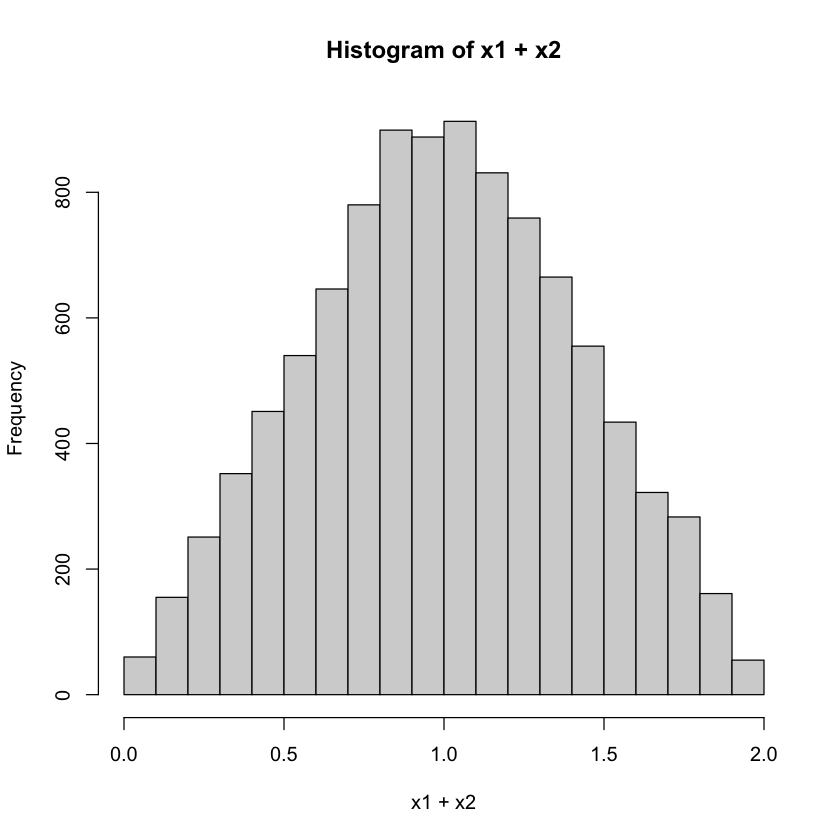

```r
hist(x1+x2)
```

Sum of two uniform distributions is not uniform distribution, looking at the histogram.

2. Is the distribution of $X_1.X_2$ uniform? Please Justify your answer.

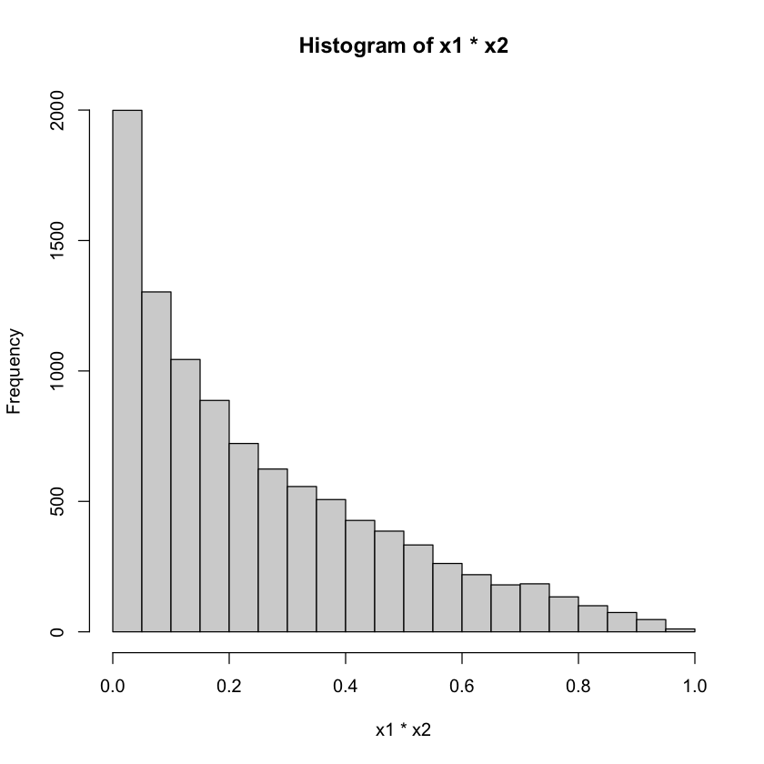

```r
hist(x1*x2)
```

Product of two uniform distribution is not uniform distribution.

3. Is the distribution of $max(X_1, X_2)$ or $min(X_1, X_2)$ uniform? Please Justify your answer.

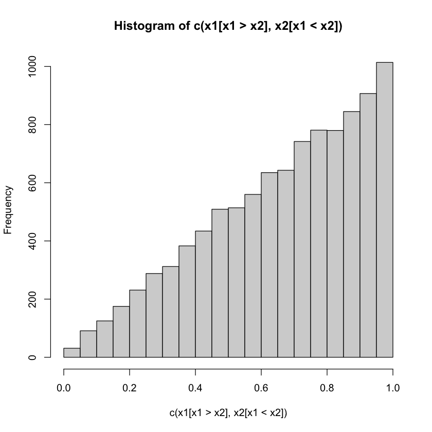

```r
hist(c(x1[x1>x2],x2[x1<x2]))
```

max(X1,X2) is not uniform distribution.

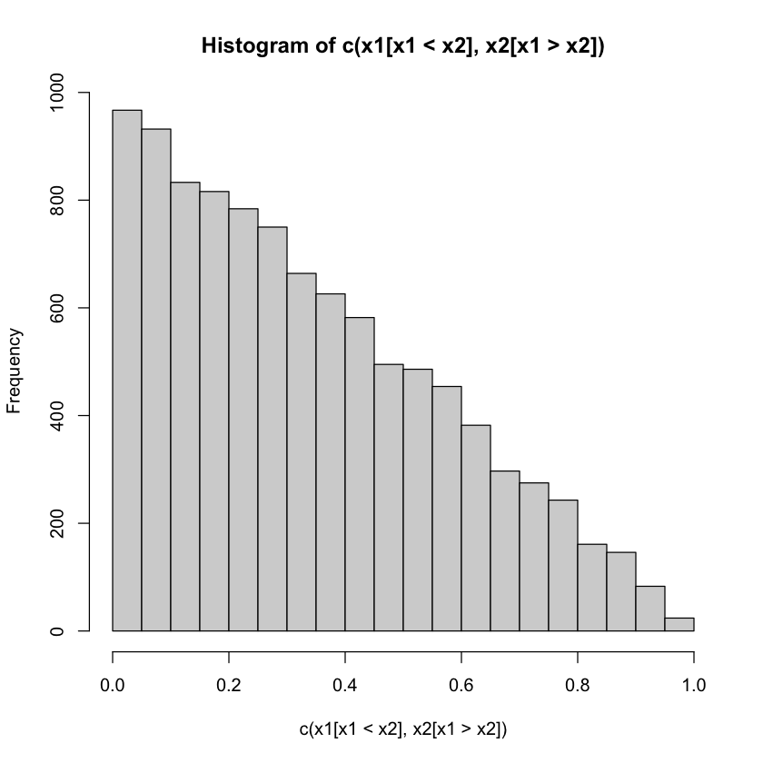

```r
hist(c(x1[x1<x2],x2[x1>x2]))
```

min(X1,X2) is not uniform distribution.

4. Is the distribution of $1-X_1$ uniform? Please Justify your answer.

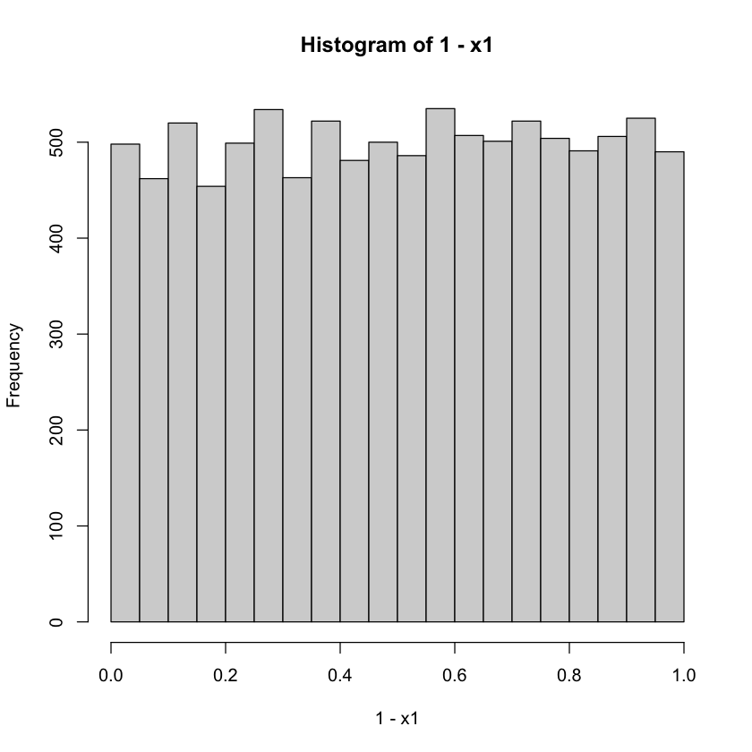

```r
hist(1-x1)
```

## Problem 2:

Validate the following theorems using simulation. (You can use parameters of your choice)

`optional`: In addition to the simulation, you can also prove these theorems analytically, i.e. with pen and paper, if you want.

1. Linear Transformations

**Theorem-5.6.4:** If $X$ has the normal distribution with mean $\mu$ and variance $\sigma^2$ and if $Y=a X+b$, 5.6.4 where $a$ and $b$ are given constants and $a \neq 0$, then $Y$ has the normal distribution with mean $a \mu+b$ and variance $a^2 \sigma^2$.

```r
x = rnorm(10000)
a = 2
b = 3
y = a*x + b
```

```r
mean(y) == a*mean(x)+b
var(y) == (a**2)*var(x)
```

TRUE

TRUE

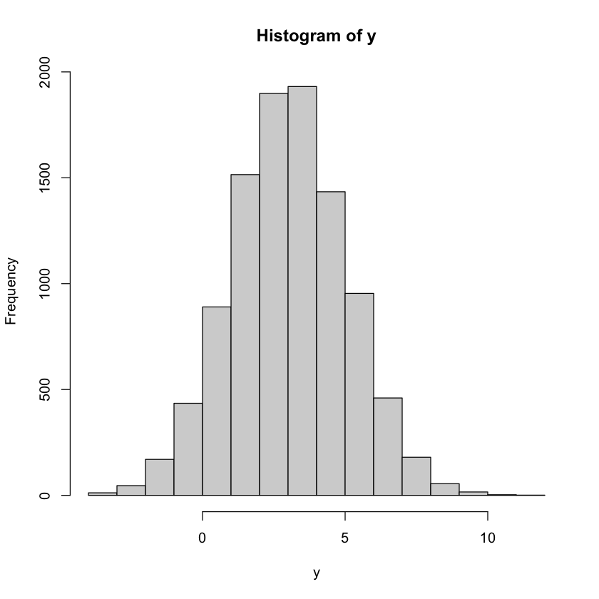

```r
hist(y)
```

As you can see, $y$ has mean $a \mu+b$ and variance $a^2 \sigma^2$.

2. Linear Combinations of Normally Distributed Variables

**Theorem-5.6.7:** If the random variables $X_1, \ldots, X_k$ are independent and if $X_i$ has the normal distribution with mean $\mu_i$ and variance $\sigma_i^2(i=1, \ldots, k)$, then the sum $X_1+\cdots+X_k$ has the normal distribution with mean $\mu_1+\cdots+\mu_k$ and variance $\sigma_1^2+\cdots+\sigma_k^2$.

```r
k = 10
iter = 1000
X = data.frame(matrix(nrow = iter, ncol = k))
for(i in 1:k){
    X[,i]=rnorm(iter)
}
X["Sum"] = rowSums(X)
```

```r
sum(sapply(X[,1:k],mean))
mean(X$Sum)
```

-0.0199020942619781

-0.0199020942619781

```r
sum(sapply(X[,1:k],var))
var(X$Sum)
```

10.1319406385384

10.3631933943085

## Problem 3:

Use the iris data set to check the normality of Sepal width of setosa using the following normality tests (Repeat the steps in the example 3 in lab 4, comment on your results)

```r
library(nortest)
setosa = iris$Sepal.Width[iris$Species == "setosa"]
m = mean(setosa)
s = sd(setosa)
```

1. Anderson Darling Test

```r
ad.test(setosa)
```

```
    Anderson-Darling normality test

data:  setosa
A = 0.49096, p-value = 0.2102
```

Having a p-value(0.2102) more than 0.05, we fail to reject null hypothesis, which is Sepal width of setosa is most likely to be a normal distribution.

2. Kolmogorov-Smirnov Test (Comapre to a standard normal distribution)

```r
ks.test(setosa,"pnorm",m,s)
```

```
    Asymptotic one-sample Kolmogorov-Smirnov test

data:  setosa
D = 0.10468, p-value = 0.6437
alternative hypothesis: two-sided
```

Similarly here, the distribution of Sepal width of setosa is most likely normal having a pvalue of 0.6437 from the test.

## Problem 4: (optional)

`Exponential Distribution`

Given exponentially distributed random variables $X_1, . . . , X_k$ . Think of waiting times for independent random alarm clocks $1,...,k$ to go off.

Which of these are again exponentially distributed? Explore with a simulation. (Hint: you can use many methods here to compare the distributions, for example; using Kolmogorov-Smirnov Test, plotting cdfs or ecdfs(as we did in lab 3),..etc )

```r
k = 10
iter = 1000
X = data.frame(matrix(nrow = iter, ncol = k))
for(i in 1:k){
    X[,i]=rexp(iter)
}
```

1. Distribution of $min(X_1,\dots,X_k)$? Waiting time for the first alarm to go off.
2. Distribution of $max(X_1, \dots, X_k )$? Waiting time for the last alarm to go off.
3. Distribution of $X_1 + \dots + X_k$ ? Waiting time until Start of the next clock when the previous alarm/s has gone off.